# Predicting the price of used cars

Martin Cadek

2021-07-11

# Introduction

The following report discusses the approach to create the final model that achieved the best performance to predict the price of used cars. The core packages used in this analysis are `data.table` and `tidymodels`.

# Basic EDA

The following EDA was conducted to understand the data using `data.table`.

Are there any NAs?

```
##        price        brand        model         year title_status      mileage        color
##            0            0            0            0            0            0            0
##          vin          lot        state      country    condition
##            0            0            0            0            0
```

Are there any duplicated values?

```
##        price        brand        model         year title_status      mileage        color
##          790           28          127           30            2         2439           49
##          vin          lot        state      country    condition
##         2495         2495           44            2           47
```

Which are duplicated?

```
##    price     brand    model year      title_status mileage color               vin       lot
## 1:    50 chevrolet     door 2008 salvage insurance  172102  blue 1g1al58f787159241 167650632
## 2:     0 chevrolet     door 2003 salvage insurance  194673  gray 1gndt13s632267445 167650636
## 3:    25 chevrolet   pickup 2010 salvage insurance  149189 white 3gcrkse37ag234620 167650663
## 4: 26900 chevrolet traverse 2018     clean vehicle   42941 black 1gnevhkw8jj148388 167781794
##       state country     condition
## 1:    texas     usa 17 hours left
## 2:    texas     usa 17 hours left
## 3: colorado     usa 17 hours left
## 4: missouri     usa 19 hours left
```

Further unusual values were also investigated, specifically, it was found that 66 observations had price < 100, 18 had mileage < 10, and 2 were older than 1990.

Finally, both categorical and numerical values were investigated.

The EDA findings led to the decision to remove any duplicated values, merge the brand and car of the model into a new variable called brand_model, coerce condition expired to a numerical variable, and remove all cars that had mileage or price of zero. The detailed process is in clean.R script. Cleaned data were saved as cleaned_USA_cars_datasets.csv and were used in further modelling.

# Data pre-processing

Before working with data, it was essential to pre-process them as some of the utilised models perform better when, for example, numerical values are on the same scale and centred.

1. The variables year, state, brand_model, and colour had their uncommon levels merged into a new level called other.
2. All nominal variables were one-hot encoded.
3. All numerical variables were scaled.
4. All numerical variables were centred.

# Splitting and Cross-validation

All of the data were split into training and test sets. The training set has been allocated 75% of the data. The testing set had been allocated the remaining 25% of all data.

All models were trained using cross-validation that was set on k = 5 of folds. Higher rates could be used, but parallelisation would be necessary, and this was not implemented as it is unknown where else the code may be run. The cross-validation did not implement stratification or repeats.

# Training the models

The models were trained on the following dataset, with the outcome variable I aimed to predict was the price of the used cars.

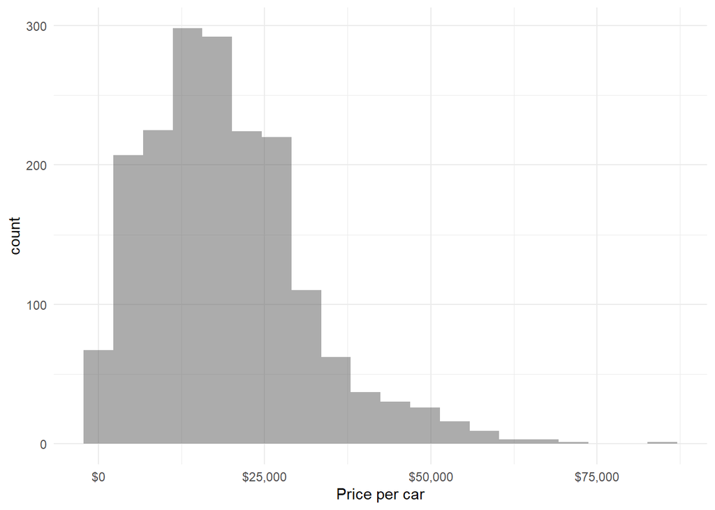

The following algorithms were selected:

- Random forests
- XGboost
- Lasso regression
- Ridge regression
- Linear (ordinary least squares) regression

All models were trained using the specifications above, and tuning was implemented to include a range of possible values rather than a fixed value. For example, the Random forest model trees parameter was trained in the range from 500 to 1000.

# Metrics

The following metrics were used to determined the accuracy of the models.

- Mean absolute error (*MAE*) provides errors in the same units as the original data and measures the accuracy of the models.
- Root mean squared error (*RMSE*) also provides the same units as the original data. This was the metric used to determine the accuracy of the models.
- Coefficient of determination or R squared (*RSQ*) is a squared correlation between truth and estimate and can be interpreted as “variance explained” or, more formally, a goodness of fit.

# Results

The following performance was achieved across all trained models when they were predicted on test data. The best models were selected as the models that had the lowest RMSE from all the trained models in each fold.

[figure not shown]

The following performance was achieved across the models shown above.

| model | .metric | .estimator | .estimate |
| --- | --- | --- | --- |
| Lasso Regression | rsq | standard | 0.27 |
| Linear Regression (OLS) | rsq | standard | 0.27 |
| Ridge Regression | rsq | standard | 0.28 |
| XGboost | rsq | standard | 0.44 |
| Random Forest | rsq | standard | 0.44 |
| Random Forest | mae | standard | 6507.29 |
| XGboost | mae | standard | 6667.15 |
| Ridge Regression | mae | standard | 7633.57 |
| Linear Regression (OLS) | mae | standard | 7635.71 |
| Lasso Regression | mae | standard | 7638.07 |
| Random Forest | rmse | standard | 9037.39 |
| XGboost | rmse | standard | 9216.31 |
| Ridge Regression | rmse | standard | 10281.68 |
| Linear Regression (OLS) | rmse | standard | 10290.50 |
| Lasso Regression | rmse | standard | 10295.40 |

Investigating the metrics and lines of best fit presented above, it was determined that the best performing model was one of the iterations from Random forest algorithms.

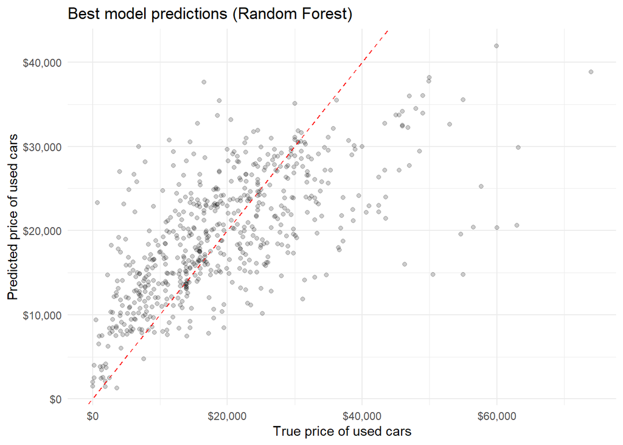

The final model had the following performances across RMSE, RSQ, and MAE metrics.

| .metric | .estimator | .estimate |
| --- | --- | --- |
| rmse | standard | 9037.39 |
| rsq | standard | 0.44 |
| mae | standard | 6507.29 |